# Introduction to SESraster

Neander Heming, Flávio Mota and Gabriela Alves-Ferreira

2023-07-04

## Contents

- Introduction
- Installation
- Analysis
- References

## Introduction

Null models have been widely used to analyze the patterns observed in nature in the attempt to understand the ecological and evolutionary mechanisms structuring the biological communities. A null model is a simplified representation of how species would be distributed or biological communities be assembled if specific ecological processes were not operating. Until now, algorithms were designed to create null models using matrix data. The package [`SESraster`](https://github.com/HemingNM/SESraster) covers a current gap by implementing randomization algorithms to build null models using presence/absence raster data.

## Installation

```r
install.packages("SESraster")
library(SESraster)
```

The development version of `SESraster` can be installed from the [SESraster repository in Github](https://github.com/HemingNM/SESraster):

```r
require(devtools)
devtools::install_github("HemingNM/SESraster", build_vignettes = TRUE)
library(SESraster)
```

## Analysis

The `SESraster` package implements functions to randomize presence/absence species distribution raster data with or without including spatial structure for calculating Standardized Effect Sizes (SES) necessary for null hypothesis testing. The function `bootspat_naive()` does not retain the spatial structure of community richness and species distribution size at the same time. It randomizes a raster stack according to the observed frequency of presences for each species (layer) using any of the following methods: sites (raster cells), species (raster layers) or both (layers and cells). This, randomization without retaining spatial structure of data, is the most commonly used method of randomization for community data. The function `bootspat_str()` does retain the spatial structure of community richness and species distribution size at the same time. It randomizes a raster stack keeping the species richness fixed across raster cells. To our knowledge this method was not previously implemented in `R`.

Let’s see some examples.

### Random species generation

Now, let’s see some of the package features. First, we will create some random species distributions using the package `terra`.

```r
library(SESraster)
library(terra)
```

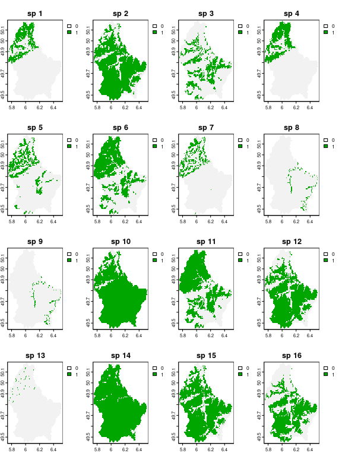

```r
# creating random species distributions
f <- system.file("ex/elev.tif", package="terra")
r <- rast(f)
set.seed(510)
r10 <- rast(lapply(1:18,
                function(i, r, mn, mx){
                  app(r, function(x, t){
                    sapply(x, function(x, t){
                       x<max(t) & x>min(t)
                    }, t=t)
                  }, t=sample(seq(mn, mx), 2))
                }, r=r, mn=minmax(r)[1]+10, mx=minmax(r)[2]-10))

names(r10) <- paste("sp", 1:nlyr(r10))
plot(r10)
```

With the distributions in hand, we can perform the spatial randomizations.

### Spatially Unstructured Randomization

First, let’s randomize species distribution ignoring the spatial structure with the function `bootspat_naive`.

#### both, by site and species simultaneously: Equiprobable-Equiprobable

We can randomize the presences/absences (1s/0s) using the method `both`. This method combines randomization by site and species at the same time. It will shuffle all presences across cells and layers, changing site richness and species distribution sizes and location at the same time. It is equivalent to the SIM1 (equiprobable-equiprobable) method of Gotelli (2000). Notice that NA cells are ignored.

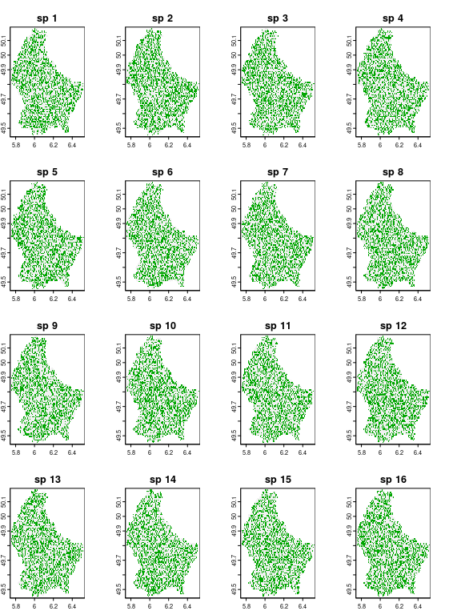

```r
srb <- bootspat_naive(r10, random = "both")
plot(srb, legend=F)
```

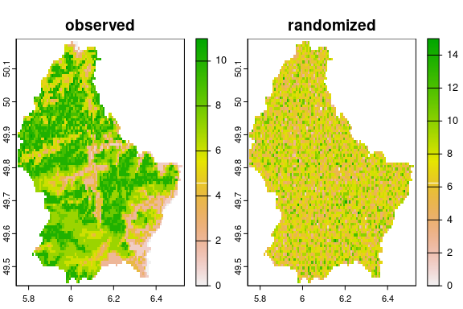

```r
plot(c(sum(r10), sum(srb)), main=c("observed", "randomized"))
```

#### by species: Fixed-Equiprobable

We can randomize by `species`. This second method is performed at each layer (species) of the stack by randomizing the position of species presences in space. If the data fits to the computer RAM memory this randomization is equivalent to the SIM2 (fixed-equiprobable) method of Gotelli (2000) and to the flatland model of Laffan & Crisp (2003). It changes the species richness at each cell while retaining the size of the species distribution (except if randomization is performed by frequency). When running by frequency, presences/absences (1s/0s) are sampled at each pixel based on the probability (frequency) that the species is found within the study area. It is equivalent to the SIM7 (proportional-equiprobable) method of Gotelli (2000). For each species, the randomized frequency of presences is very similar to the actual frequency but not exactly the same.

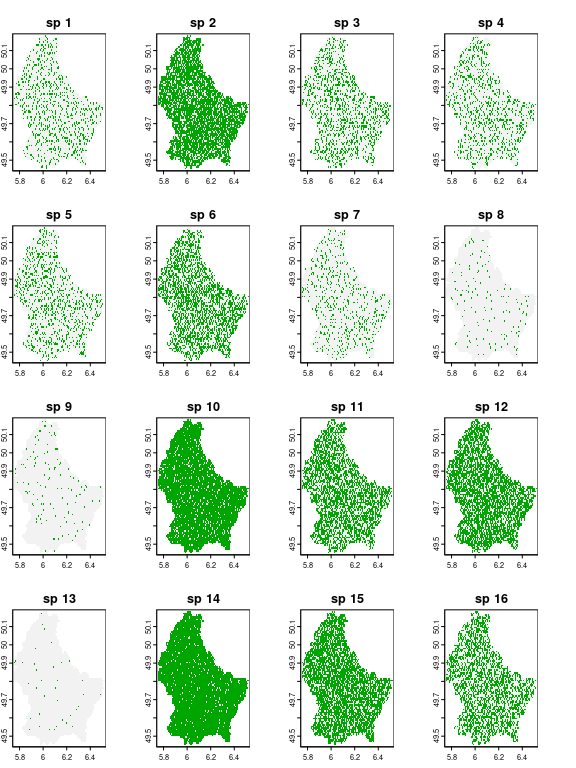

```r
sr1 <- bootspat_naive(r10, random = "species")
plot(sr1, legend=F)
```

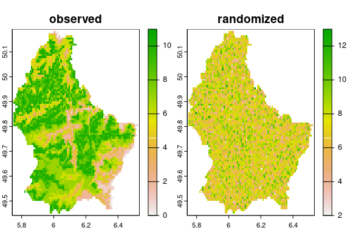

```r
plot(c(sum(r10), sum(sr1)), main=c("observed", "randomized"))
```

```r
sr1b <- bootspat_naive(r10, random = "species", memory = FALSE)
```

```
#> The file does not fit on the memory. Randomization will be done by probability.
```

Check that the number of occupied pixels of randomized distributions are similar to those of the observed distributions.

```r
cbind(observed=sapply(r10, function(x)freq(x)[2,3]),
      randomized=sapply(sr1, function(x)freq(x)[2,3]),
      randomized_freq=sapply(sr1b, function(x)freq(x)[2,3]))
```

```
#>       observed randomized randomized_freq
#>  [1,]      767        767             773
#>  [2,]     3443       3443            3452
#>  [3,]     1175       1175            1180
#>  [4,]      889        889             872
#>  [5,]      908        908             952
#>  [6,]     2160       2160            2143
#>  [7,]      548        548             544
#>  [8,]      133        133             127
#>  [9,]      122        122             118
#> [10,]     4174       4174            4171
#> [11,]     2565       2565            2502
#> [12,]     3031       3031            3029
#> [13,]       36         36              35
#> [14,]     4387       4387            4398
#> [15,]     3270       3270            3235
#> [16,]     2198       2198            2216
#> [17,]     2427       2427            2392
#> [18,]      235        235             229
```

#### by site: Equiprobable-Fixed

Now, we will randomize by `site`. This method randomizes the position (presence/absence) of the species within each site (cell) of the stack. This method keeps species richness constant at each cell but the size of the species distribution might change, as more or less pixels can be randomly assigned to each species (raster layer). This randomization is equivalent to the SIM3 (equiprobable-fixed) method of Gotelli (2000). Notice that, although the spatial structure of species richness is held constant, the number of pixels that each species occupy is completely randomized.

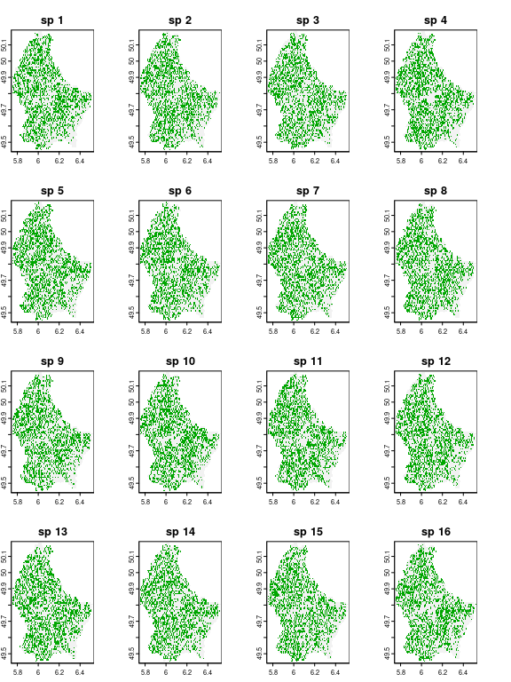

```r
sr2 <- bootspat_naive(r10, random = "site")
plot(sr2, legend=F)
```

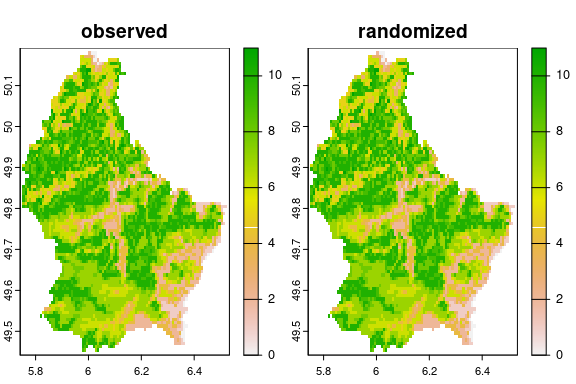

```r
plot(c(sum(r10), sum(sr2)), main=c("observed", "randomized"))
```

### Spatially Structured Randomization

Notice that randomization by `site` from `bootspat_naive()` keeps the species richness fixed (i.e. equal to the input raster), but the size of the species’ distribution (i.e. number of pixels of each species) is completely randomized. On the other hand, randomization by `species` keeps the number of pixels of each species fixed, but the richness is completely randomized. The functions `bootspat_str()` and `bootspat_ff()` add some constraints to the randomization. See below:

#### function `bootspat_str()`: Fixed-Proportional

In the function `bootspat_str()` we implement a spatially structured randomization that keeps the species richness pattern fixed and distribution size of each species, proportional. This method is based on the second null model of Laffan & Crisp (2003), but uses probability of sampling presences based on frequency of presences for each species. Therefore, it is equivalent to the SIM5 (proportional-fixed) method of Gotelli (2000). Notice that it will lack spatial structure in the same way of randomization by `site`, however the size of the species distribution is (nearly) retained.

Randomizations are based on frequencies (given or calculated from the output raster (a presence-absence SpatRaster) and, optionally, a probability raster stack. Both, the frequency vector and the probability raster stack, control the probability that a given species is sampled in each raster cell. The frequency vector controls the probability of sampling each species compared to all others. The probability raster stack controls the probability that each species is sampled on a given raster cell.

```r
# bootstrapping once
fr.prob <- SESraster::fr2prob(r10)
prob <- terra::app(r10,
                   function(x){
                     ifelse(is.na(x), 0, 1)
                   })

randr10 <- bootspat_str(r10, rprob = prob, fr_prob = fr.prob)
```

The species distribution was spatially randomized according to the frequency of presence of each species. This method randomizes the position of species presences in space keeping the species richness constant and number of occupied pixels of randomized distributions very similar those on the actual distributions.

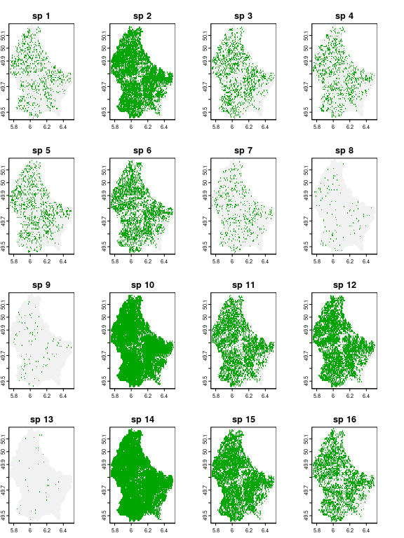

```r
plot(randr10, legend=F)
```

See unchanged spatial pattern of species richness.

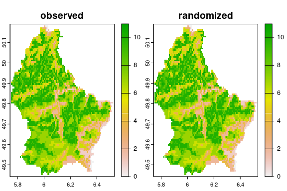

```r
plot(c(sum(r10), sum(randr10)), main=c("observed", "randomized"))
```

Check that the number of occupied pixels of randomized distributions are very similar those of the observed distributions.

```r
cbind(observed=sapply(r10, function(x)freq(x)[2,3]),
      randomized=sapply(randr10, function(x)freq(x)[2,3]))
```

```
#>       observed randomized
#>  [1,]      767        681
#>  [2,]     3443       3532
#>  [3,]     1175       1119
#>  [4,]      889        849
#>  [5,]      908        832
#>  [6,]     2160       2138
#>  [7,]      548        461
#>  [8,]      133        104
#>  [9,]      122         95
#> [10,]     4174       4246
#> [11,]     2565       2602
#> [12,]     3031       3127
#> [13,]       36         32
#> [14,]     4387       4413
#> [15,]     3270       3379
#> [16,]     2198       2193
#> [17,]     2427       2483
#> [18,]      235        182
```

#### function `bootspat_ff()`: Fixed-Fixed

In the function `bootspat_ff()` we implement a spatially structured randomization that keeps both, the species richness pattern and species distribution size, fixed. This method is equivalent to the SIM9 (fixed-fixed) method of Gotelli (2000) and is based on the null model of Connor & Simberloff (1979), but has some differences.

The original algorithm randomly chooses the sequence of species and fills sites (originally islands) until they reach the observed species richness. However, as sites (cells) are filled with species, some species do not have enough available sites to be placed, and their sampled frequency is smaller than observed. Additionally, some sites cannot be completely filled because duplicated species are not allowed in the same site. Their solution was to increase the number of sites to place the species. Here, we opted to order the sequence of species from the largest Nj to the smallest. Our algorithm is usually able to match the constraints (site richness and distribution size) but in some cases, specially with small datasets, some sites lack on species to match the original richness and some species are assigned to less sites than originally observed.

```r
# bootstrapping once
randff <- bootspat_ff(r10)
```

See how species distribution sizes are maintained. Compare the original and null distributions. Plots are sorted from the largest to the smallest distributions.

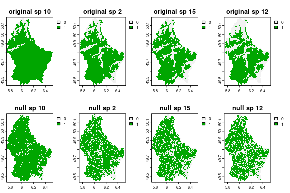

```r
obs_fr <- unlist(terra::global(r10, function(x) sum(x, na.rm = TRUE)))
v_seq <- order(obs_fr)
plot(c(r10[[v_seq[length(v_seq)-1:4]]], randff[[v_seq[length(v_seq)-1:4]]]),
     nr=2, main=paste(rep(c("original", "null"), each=4), names(r10[[v_seq[length(v_seq)-1:4]]])))
```

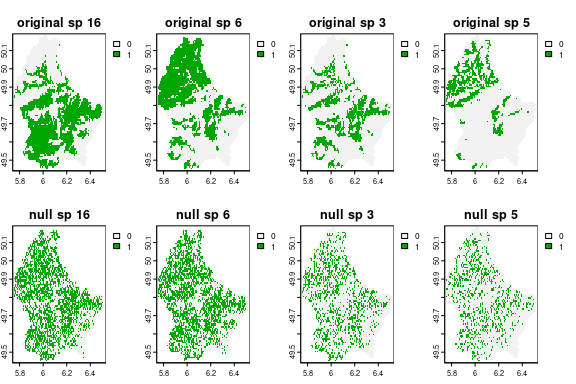

```r
plot(c(r10[[v_seq[floor(length(v_seq)/2) + 2:-1]]], randff[[v_seq[floor(length(v_seq)/2)+ 2:-1]]]),
     nr=2, main=paste(rep(c("original", "null"), each=4), names(r10[[v_seq[floor(length(v_seq)/2)+ 2:-1]]])))
```

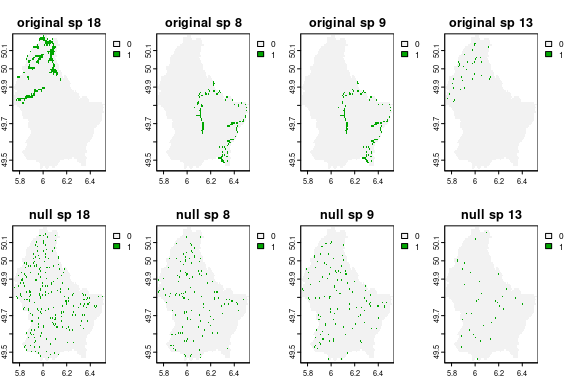

```r
plot(c(r10[[v_seq[4:1]]], randff[[v_seq[4:1]]]),
     nr=2, main=paste(rep(c("original", "null"), each=4), names(r10[[v_seq[4:1]]])))
```

See unchanged spatial pattern of species richness.

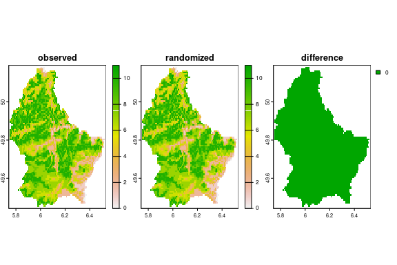

```r
plot(c(sum(r10), sum(randff), sum(r10)-sum(randff)), main=c("observed", "randomized", "difference"), nr=1)
```

Check that the number of occupied pixels of randomized distributions are very similar those of the observed distributions.

```r
cbind(observed=sapply(r10, function(x)freq(x)[2,3]),
      randomized=sapply(randff, function(x)freq(x)[2,3]))
```

```
#>       observed randomized
#>  [1,]      767        767
#>  [2,]     3443       3443
#>  [3,]     1175       1175
#>  [4,]      889        889
#>  [5,]      908        908
#>  [6,]     2160       2160
#>  [7,]      548        548
#>  [8,]      133        133
#>  [9,]      122        122
#> [10,]     4174       4174
#> [11,]     2565       2565
#> [12,]     3031       3031
#> [13,]       36         36
#> [14,]     4387       4387
#> [15,]     3270       3270
#> [16,]     2198       2198
#> [17,]     2427       2427
#> [18,]      235        235
```

## References

Connor, Edward F., and Daniel Simberloff. 1979. “The Assembly of Species Communities: Chance or Competition?” *Ecology* 60 (6): 1132–40. https://doi.org/10.2307/1936961.

Gotelli, Nicholas J. 2000. “Null Model Analysis of Species Co-Occurrence Patterns.” *Ecology* 81 (9): 2606–21. https://doi.org/10.2307/177478.

Laffan, Shawn W., and Michael D. Crisp. 2003. “Assessing Endemism at Multiple Spatial Scales, with an Example from the Australian Vascular Flora.” *Journal of Biogeography* 30 (4): 511–20. https://doi.org/10.1046/j.1365-2699.2003.00875.x.